# 2019-2024

Cargamos las librerías necesarias.

```r
library(COINr)
library(dplyr)
library(tidyr)
library(caret)
library(lubridate)
library(ggplot2)
library(stringr)
library(mice)
library(scales)
library(knitr)
library(psych)
library(purrr)
library(ggcorrplot)
library(naniar)
library(VIM)
library(performance)
```

Cargamos los datos y los retocamos para que nos cuadre con la estructura que necesita COINr.

```r
# Cargamos los 3 dfs: el de los valores, el de los metadatos y el df completo.
indicadores_calculados_final <- readRDS("../data/cindicators.rds")
indicators_meta_final <- readRDS("../data/indicators.rds")
df_indicadores_completo_final <- readRDS("../data/df_indicadores_completo.rds")

regiones_a_analizar <- c("ES-AN","ES-CT","ES-MD","ES-VC")
quito_anios <- c(2016,2017,2018,2025)
# Renombramos la columna valor, eliminamos la source_id que es la misma para todos y no aporta nada, quito 2025 (faltan datos de muchos indicadores)
indicadores_calculados_final <- indicadores_calculados_final |>
  rename(value = indicator_value) |>
  select(-source_id) |>
  # Creamos el año y filtramos para quitar 2025
  mutate(Year = year(as.Date(date))) |>
  filter(!(Year %in% quito_anios)) |>
  filter(geo_id %in% regiones_a_analizar)

# Verificamos cuántos indicadores tenemos en total
indicadores_activos <- indicadores_calculados_final |>
  pull(indicator_id) |>
  unique()

cat("Indicadores detectados:", length(indicadores_activos), "\n")
```

```
Indicadores detectados: 52
```

# iData

Es el df que tiene por columnas: uCode (que es nuestro código de cada región), Time (que son nuestros años) y todos los indicadores individuales. Por tanto, las filas son los valores que corresponden a cada región en cada año.

```r
# Transformamos a formato ancho
iData <- indicadores_calculados_final |>
  mutate(Time = year(as.Date(date))) |>
  select(uCode = geo_id, Time, indicator_id, value) |>
  pivot_wider(names_from = indicator_id, values_from = value)

# Paso los NaN a NA para tenerlo todo igual
#iData[do.call(cbind, lapply(iData, is.nan))] <- NA # se supone que lo he gestionado ya en el gen_data_local

head(iData)
```

```
# A tibble: 6 × 54
  uCode  Time IAMB0001 IAMB0002 IAMB0006 IAMB0007 IECO0001 IECO0002 IECO0005
  <chr> <dbl>    <dbl>    <dbl>    <dbl>    <dbl>    <dbl>    <dbl>    <dbl>
1 ES-AN  2019     90.0    5.01      81.3    18.7      124.    1032.     8.31
2 ES-CT  2019     93.1    5.20      72.5    27.5      197.    1100.     5.58
3 ES-MD  2019     96.2    1.08      93.0     7.04     271.    1368.     5.05
4 ES-VC  2019     95.8    1.75      79.5    20.5      108.    1002.     9.28
5 ES-AN  2021     92.1    0.744     85.3    14.7      114.    1122.     9.84
6 ES-CT  2021     92.8    3.88      57.7    42.3      154.     954.     6.19
# ℹ 45 more variables: IECO0009 <dbl>, IECO0018 <dbl>, IECO0019 <dbl>,
#   IECO0026 <dbl>, IECO0027 <dbl>, IECO0029 <dbl>, IECO0032 <dbl>,
#   IECO0033 <dbl>, IECO0034 <dbl>, IECO0035 <dbl>, IECO0036 <dbl>,
#   IECO0037 <dbl>, IECO0038 <dbl>, IECO0039 <dbl>, IECO0040 <dbl>,
#   IECO0041 <dbl>, IECO0042 <dbl>, IECO0043 <dbl>, IECO0044 <dbl>,
#   IECO0045 <dbl>, IECO0046 <dbl>, IECO0047 <dbl>, IECO0048 <dbl>,
#   IECO0049 <dbl>, IECO0050 <dbl>, IECO0051 <dbl>, IECO0052 <dbl>, …
```

Ahora quiero ver de cuántos indicadores tengo datos por año y por región.

```r
# Obtenemos los años únicos ordenados
anios <- sort(unique(iData$Time))

for(anio in anios){
  cat("\n--- Indicadores que tienen datos en el año:", anio, "---\n")

  res <- iData |>
    filter(Time == anio) |>
    rowwise() |>
    mutate(datos_reales = sum(!is.na(c_across(-c(uCode, Time))))) |>
    select(uCode, datos_reales)

  print(res)
}
```

```
--- Indicadores que tienen datos en el año: 2019 ---
# A tibble: 4 × 2
# Rowwise:
  uCode datos_reales
  <chr>        <int>
1 ES-AN           49
2 ES-CT           49
3 ES-MD           49
4 ES-VC           49

--- Indicadores que tienen datos en el año: 2020 ---
# A tibble: 4 × 2
# Rowwise:
  uCode datos_reales
  <chr>        <int>
1 ES-AN           45
2 ES-CT           45
3 ES-MD           45
4 ES-VC           44

--- Indicadores que tienen datos en el año: 2021 ---
# A tibble: 4 × 2
# Rowwise:
  uCode datos_reales
  <chr>        <int>
1 ES-AN           52
2 ES-CT           52
3 ES-MD           52
4 ES-VC           52

--- Indicadores que tienen datos en el año: 2022 ---
# A tibble: 4 × 2
# Rowwise:
  uCode datos_reales
  <chr>        <int>
1 ES-AN           52
2 ES-CT           52
3 ES-MD           52
4 ES-VC           52

--- Indicadores que tienen datos en el año: 2023 ---
# A tibble: 4 × 2
# Rowwise:
  uCode datos_reales
  <chr>        <int>
1 ES-AN           51
2 ES-CT           51
3 ES-MD           51
4 ES-VC           51

--- Indicadores que tienen datos en el año: 2024 ---
# A tibble: 4 × 2
# Rowwise:
  uCode datos_reales
  <chr>        <int>
1 ES-AN           51
2 ES-CT           51
3 ES-MD           51
4 ES-VC           51
```

```r
resumen_disponibilidad <- iData |>
  pivot_longer(cols = -c(uCode, Time), names_to = "indicador", values_to = "valor") |>
  group_by(Time, uCode) |>
  summarise(total_datos = sum(!is.na(valor)), .groups = "drop") |>
  pivot_wider(names_from = Time, values_from = total_datos)
```

# Indicadores problemáticos

Estudiamos los indicadores que pueden darnos problemas, que son los que tengan varianza 0, es decir, los constantes. Para detectarlos podemos ver dónde min == max.

```r
# Calculamos min y max por cada indicador y cada año
# Quitamos uCode porque al ser character nos puede dar error.
stats <- iData |>
  select(-uCode) |>
  group_by(Time) |>
  summarise(across(where(is.numeric), list(
    min = \(x) min(x, na.rm = TRUE),
    max = \(x) max(x, na.rm = TRUE)
  ), .names = "{.col}_{.fn}")) |>
  pivot_longer(
    cols = -Time,
    names_to = c("iCode", ".value"),
    names_pattern = "(.*)_(.*)"
  )

# Los que tienen min == max nos darán problemas (NaN) al normalizar
indicadores_con_problemas <- stats |>
  filter(min == max) |>
  select(Time, iCode, min, max)

print(indicadores_con_problemas, n=100)
```

```
# A tibble: 0 × 4
# ℹ 4 variables: Time <dbl>, iCode <chr>, min <dbl>, max <dbl>
```

```r
# Lista con los nombres únicos
nombres_problematicos <- indicadores_con_problemas |>
  pull(iCode) |>
  unique()

print("Indicadores a revisar:")
```

```
[1] "Indicadores a revisar:"
```

```r
print(nombres_problematicos)
```

```
character(0)
```

# Disponibilidad de datos por indicador

```r
disponibilidad <- iData |>
  filter(uCode != "ESP") |>
  # Calculamos el % de datos no NA para cada columna (excepto uCode y Time)
  summarise(across(-c(uCode, Time), ~ sum(!is.na(.x)) / n())) |>
  # Pasamos a formato largo para que sea una lista
  pivot_longer(everything(), names_to = "iCode", values_to = "disponibilidad") |>
  # Lo multiplicamos por 100 para que sea porcentaje y redondeamos
  mutate(disponibilidad_Pct = round(disponibilidad * 100, 2)) |>
  # Ordenamos para ver primero los que tienen menos datos
  arrange(disponibilidad_Pct)

# Tabla completa
df_disponibilidad_datos <- as.data.frame(disponibilidad)

# Indicadores que mantenemos: los que tengan más del 20% de datos disponibles
indicadores_a_mantener <- disponibilidad |> filter(disponibilidad_Pct>=20) |> pull(iCode)

# Vemos cuáles deberíamos eliminar:
eliminados <- disponibilidad |> filter(disponibilidad_Pct<20) |> pull(iCode)
print(paste("Indicadores eliminados por baja disponibilidad:", length(eliminados)))
```

```
[1] "Indicadores eliminados por baja disponibilidad: 0"
```

```r
print(eliminados)
```

```
character(0)
```

# Eliminamos indicadores con baja disponibilidad

```r
# Indicadores a eliminar (baja disponibilidad, pero mantengo 4 ambientales porque si no me quedo sin la dimensión ENV)
indicadores_eliminar <- c("IAMB0004", "IAMB0005", "IAMB0003", "IECO0012", "IECO0013", "ISOC0004")

# Filtramos iData eliminando esos indicadores
iData_clean <- iData |>
  select(-any_of(indicadores_eliminar)) |>
  filter(uCode != "ESP")

# Verificación
print(paste("Indicadores restantes:", ncol(iData_clean) - 2)) # -2 por uCode y Time
```

```
[1] "Indicadores restantes: 52"
```

# iMeta

Es el df de los metadatos, lo más importante es que contiene los códigos con los nombres completos y los pesos!! Como tenemos varios niveles para crear el IC, construimos el iMeta igual, en 3 niveles.

```r
df <- indicators_meta_final |>
  select(-any_of("dimension_id")) |>
  left_join(
    df_indicadores_completo_final |>
      select(indicator_id, dimension_id) |>
      distinct(),
    by = "indicator_id"
  )

#  NIVEL 1: INDICADORES
iMeta_L1 <- df |>
  select(
    iCode     = indicator_id,
    iName     = indicator_original_name,
    Parent    = dimension_id,
    Direction = indicator_direction,
    Weight    = indicator_weight
  ) |>
  distinct(iCode, .keep_all = TRUE) |>
  # Filtramos los que hemos decidido eliminar por baja disponibilidad
  filter(!iCode %in% indicadores_eliminar) |>
  mutate(
    Direction = ifelse(Direction == "+", 1, -1),
    Level = 1,
    Type  = "Indicator"
  )

#  NIVEL 2: DIMENSIONES
iMeta_L2 <- iMeta_L1 |>
  select(iCode = Parent) |>
  distinct() |>
  mutate(
    iName     = paste("Dimensión:", iCode),
    Level     = 2,
    Parent    = "TotalIndex",
    Direction = 1,
    Weight    = 1,
    Type      = "Aggregate"
  )

#  NIVEL 3: ÍNDICE FINAL
iMeta_L3 <- data.frame(
  iCode     = "TotalIndex",
  iName     = "Índice Sintético Regional",
  Level     = 3,
  Parent    = NA,
  Direction = 1,
  Weight    = 1,
  Type      = "Aggregate"
)

#  UNIÓN FINAL
iMeta <- bind_rows(iMeta_L1, iMeta_L2, iMeta_L3)

glimpse(iMeta)
```

```
Rows: 56
Columns: 7
$ iCode     <chr> "IECO0001", "IECO0002", "IAMB0001", "IECO0005", "IAMB0002", …
$ iName     <chr> "Gasto medio por turista receptor y día", "Gasto medio por t…
$ Parent    <chr> "ECO", "ECO", "ENV", "ECO", "ENV", "ENV", "ENV", "ECO", "SOC…
$ Direction <dbl> 1, 1, 1, 1, 1, -1, 1, 1, 1, 1, 1, 1, 1, 1, 1, 1, 1, 1, 1, 1,…
$ Weight    <dbl> 1, 1, 1, 1, 1, 1, 1, 1, 1, 1, 1, 1, 1, 1, 1, 1, 1, 1, 1, 1, …
$ Level     <dbl> 1, 1, 1, 1, 1, 1, 1, 1, 1, 1, 1, 1, 1, 1, 1, 1, 1, 1, 1, 1, …
$ Type      <chr> "Indicator", "Indicator", "Indicator", "Indicator", "Indicat…
```

# Purse I

```r
purse <- new_coin(
  iData    = iData_clean,
  iMeta    = iMeta,
  split_to = "all",
  quietly  = TRUE
)

purse
```

```
-----------------------------
A purse with... 6 coins
-----------------------------

 Time n_Units n_Inds n_dsets
 2019       4     52       1
 2020       4     52       1
 2021       4     52       1
 2022       4     52       1
 2023       4     52       1
 2024       4     52       1

-----------------------------------
Sample from first coin (2019):
-----------------------------------

Input:
  Units: 4 (ES-AN, ES-CT, ES-MD, ...)
  Indicators: 52 (IECO0001, IECO0002, IECO0005, ...)
  Denominators: 0 ()
  Groups: 0 (none)

Structure:
  Level 1 : 52 indicators (IECO0001, IECO0002, IECO0005, ...)
  Level 2 : 3 groups (ECO, ENV, SOC)
  Level 3 : 1 groups (TotalIndex)

Data sets:
  Raw (4 units)
```

# Imputacion MICE

Estuve trabajando con imputación por la mediana, pero me daba demasiados errores, no se cubría casi ningún NA porque no teníamos suficientes datos. Con MICE se nos cubren TODOS los NA excepto los del indicador individual IAMB0007.

Cómo funciona MICE: “El paquete mice nos ayuda a imputar valores faltantes con valores de datos plausibles. Estos valores plausibles se extraen de una distribución diseñada específicamente para cada punto de datos faltante.

La imputación múltiple es un método que aborda el problema de los valores faltantes en los conjuntos de datos al generar múltiples conjuntos de datos completos, cada uno con valores imputados de manera diferente. Luego, los resultados se combinan para obtener estimaciones finales y varianzas que reflejen la incertidumbre de la imputación.”

```r
# 1. Preparamos datos numéricos
df_raw <- get_dset(purse, dset = "Raw") #Extraemos los datos originales (Raw)
df_ids <- df_raw |> select(uCode, Time) #Guardamos aparte las oclumnas de identificación (región y año)
df_numeric <- df_raw |> select(-uCode, -Time) #Nos quedamos solo con las columnas de los indicadores. Y estas son las que MICE va a analizar para encontrar patrones.

# 2. Diagnóstico Pre-MICE
na_pre <- sum(is.na(df_numeric)) #Celdas vacías en total
total_cells <- prod(dim(df_numeric)) #Tamaño total de nuestra tabla
cat("PRE-MICE: ", na_pre, " NAs (", round(100 * na_pre / total_cells, 2), "%)\n")
```

```
PRE-MICE:  49  NAs ( 3.93 %)
```

```r
# 3. Ejecutar MICE (PMM)
#df_numeric son los datos a procesar, m=1 creamos una sola versión de datos imputados, método PMM: Predictive Mean Matching, busca valores reales existentes que cuadren según el perfil de la regón. Con maxit = 5, el algoritmo itera 5 veces para refinar sus predicciones. Fijamos seed 42.
mice_out <- mice(df_numeric, m = 1, method = "pmm", maxit = 5, seed = 42, printFlag = FALSE)
df_imputed <- complete(mice_out)

# 4. Diagnóstico Post-MICE con porcentaje
na_post <- sum(is.na(df_imputed)) #volvemos a contar los NA
cat("POST-MICE:", na_post, " NAs (", round(100 * na_post / total_cells, 2), "%)\n")
```

```
POST-MICE: 4  NAs ( 0.32 %)
```

```r
# 5. ¿Qué se ha quedado sin imputar?
if(na_post > 0){
  cols_con_na <- colSums(is.na(df_imputed))
  print("Indicadores que siguen teniendo NAs:")
  print(cols_con_na[cols_con_na > 0])
}
```

```
[1] "Indicadores que siguen teniendo NAs:"
IAMB0007
       4
```

```r
# 6. Reconstruimos iData e integramos en el purse
iData_imputed_mice <- bind_cols(df_ids, df_imputed)

purse <- new_coin(
  iData = iData_imputed_mice,
  iMeta = iMeta,
  split_to = "all",
  quietly = TRUE
)

# Marcar datos como ya imputados en cada coin del purse
# (Los datos MICE ya están imputados, así que Imputed = Raw)
for(i in seq_along(purse$coin)){
  purse$coin[[i]]$Data$Imputed <- purse$coin[[i]]$Data$Raw
}
```

Ejemplo gráfico distribución indicador IECO0033 por año.

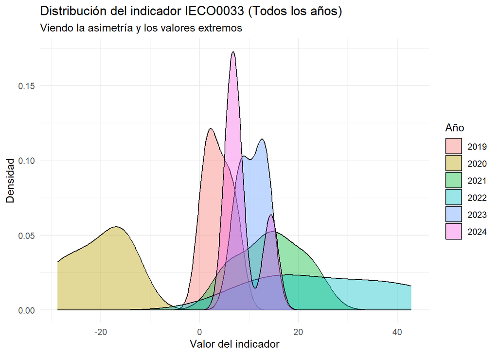

```r
# Sacamos los datos limpios de todo el panel
df_imputed <- get_dset(purse, dset = "Imputed")

# Elegimos el indicador que queremos "investigar" (ej. IECO0033)
df_imputed |>
  select(uCode, Time, IECO0033) |>
  # Hacemos un diagrama de densidad (como un histograma suavizado) para ver la "cola"
  ggplot(aes(x = IECO0033, fill = as.factor(Time))) +
  geom_density(alpha = 0.4) + # Alpha le da transparencia para ver los años superpuestos
  theme_minimal() +
  labs(
    title = "Distribución del indicador IECO0033 (Todos los años)",
    subtitle = "Viendo la asimetría y los valores extremos",
    x = "Valor del indicador",
    y = "Densidad",
    fill = "Año"
  )
```

# Tratamos outliers

```r
# 1. Aplicamos el tratamiento (Winsorización) al purse
purse <- Treat(
  purse,
  dset = "Imputed",
  f_t = "winsorise",
  f_t_para = list(na.rm = TRUE,
                  winmax = 5,
                  skew_thresh = 2,
                  kurt_thresh = 3.5,
                  force_win = TRUE)
)

# 2. Extraemos datos para comparar antes vs después
df_antes   <- get_dset(purse, "Imputed")
df_despues <- get_dset(purse, "Treated")

# 3. Métricas de escala anuales para dar contexto
metricas_escala <- df_antes |>
  pivot_longer(-c(uCode, Time), names_to = "iCode", values_to = "valor") |>
  group_by(Time, iCode) |>
  summarise(
    Media_Anual   = mean(valor, na.rm = TRUE),
    Mediana_Anual = median(valor, na.rm = TRUE),
    Max_Absoluto  = max(valor, na.rm = TRUE),
    .groups = "drop"
  )

# 4. Construcción de la tabla base de outliers
tabla_outliers <- df_antes |>
  pivot_longer(-c(uCode, Time), names_to = "iCode", values_to = "Original") |>
  left_join(
    df_despues |>
      pivot_longer(-c(uCode, Time), names_to = "iCode", values_to = "Tratado"),
    by = c("uCode", "Time", "iCode")
  ) |>
  filter(abs(Original - Tratado) > 1e-9) |>
  left_join(iMeta |> select(iCode, iName), by = "iCode") |>
  left_join(metricas_escala, by = c("Time", "iCode")) |>
  mutate(Vs_Media = round(Original / Media_Anual, 2)) |>
  select(
    Año = Time, CCAA = uCode, Indicador = iName,
    Original, Tratado, Media = Media_Anual,
    Mediana = Mediana_Anual, `Máx Año` = Max_Absoluto,
    `Vs Media` = Vs_Media
  )

# --- IMPRESIÓN DE RESULTADOS ---

cat("### Análisis del tratamiento de valores atípicos (Winsorización)\n")
```

```
### Análisis del tratamiento de valores atípicos (Winsorización)
```

```r
cat("Se han corregido un total de **", nrow(tabla_outliers), "** valores por superar los umbrales de asimetría y curtosis.\n\n")
```

```
Se han corregido un total de ** 0 ** valores por superar los umbrales de asimetría y curtosis.
```

```r
# A. Detalle de cambios
tabla_outliers |>
  #head(20) |>
  mutate(across(where(is.numeric), \(x) round(x, 2))) |>
  knitr::kable(caption = "Valores modificados (Original vs Tratado).")
```

Valores modificados (Original vs Tratado).

| Año | CCAA | Indicador | Original | Tratado | Media | Mediana | Máx Año | Vs Media |
| --- | --- | --- | --- | --- | --- | --- | --- | --- |

```r
# B. Resumen por Indicador
resumen_indicadores <- tabla_outliers |>
  group_by(Indicador) |>
  summarise(Casos = n()) |>
  arrange(desc(Casos))

print(knitr::kable(resumen_indicadores, caption = "Frecuencia de tratamiento por indicador."))
```

```
Table: Frecuencia de tratamiento por indicador.

|Indicador | Casos|
|:---------|-----:|
```

```r
# C. Resumen por Región (CCAA)
resumen_ccaa <- tabla_outliers |>
  group_by(CCAA) |>
  summarise(
    `Total Outliers` = n(),
    `Indicadores Afectados` = n_distinct(Indicador)
  ) |>
  arrange(desc(`Total Outliers`))

cat("\n### Frecuencia de Outliers por Comunidad Autónoma\n")
```

```
### Frecuencia de Outliers por Comunidad Autónoma
```

```r
print(knitr::kable(resumen_ccaa,
                   caption = "Detección de valores atípicos por región (total años)."))
```

```
Table: Detección de valores atípicos por región (total años).

|CCAA | Total Outliers| Indicadores Afectados|
|:----|--------------:|---------------------:|
```

```r
# D. Resumen por Año
resumen_temporal <- tabla_outliers |>
  group_by(Año) |>
  summarise(
    `Total Outliers` = n(),
    `CCAA con Outliers` = n_distinct(CCAA)
  ) |>
  arrange(Año)

cat("\n### Frecuencia de Outliers por Año\n")
```

```
### Frecuencia de Outliers por Año
```

```r
print(knitr::kable(resumen_temporal,
                   caption = "Evolución temporal de la detección de valores atípicos."))
```

```
Table: Evolución temporal de la detección de valores atípicos.

| Año| Total Outliers| CCAA con Outliers|
|---:|--------------:|-----------------:|
```